# EDA 2

```python
import numpy as np
import pandas as pd
import matplotlib.pyplot as plt
import seaborn as sns
import warnings
warnings.filterwarnings("ignore")
```

```python
sales = pd.read_csv(r'F:\DUCAT\Data Science\k_circle_sales.csv')
sales.head()
```

|  | Item_Identifier | Item_Weight | Item_Fat_Content | Item_Visibility | Item_Type | Item_MRP | Outlet_Identifier | Outlet_Establishment_Year | Outlet_Size | Outlet_Location_Type | Outlet_Type | Item_Outlet_Sales | Profit |
| --- | --- | --- | --- | --- | --- | --- | --- | --- | --- | --- | --- | --- | --- |
| 0 | FDA15 | 9.30 | Low Fat | 0.016047 | Dairy | 249.8 | OUT049 | 1999 | Medium | Tier 2 | Supermarket Type1 | 3735.1380 | 11.5 |
| 1 | DRC01 | 5.92 | Regular | 0.019278 | Soft Drinks | 48.3 | OUT018 | 2009 | Medium | Tier 2 | Supermarket Type2 | 443.4228 | 14.3 |
| 2 | FDN15 | 17.50 | Low Fat | 0.016760 | Meat | 141.6 | OUT049 | 1999 | Medium | Tier 2 | Supermarket Type1 | 2097.2700 | 14.5 |
| 3 | FDX07 | 19.20 | Regular | 0.000000 | Fruits and Vegetables | 182.1 | OUT010 | 1998 | NaN | NaN | Grocery Store | 732.3800 | 13.6 |
| 4 | NCD19 | 8.93 | Low Fat | 0.000000 | Household | 53.9 | OUT013 | 1987 | High | Tier 3 | Supermarket Type1 | 994.7052 | 14.1 |

```python
# Size of the dataset

sales.size
```

```
110799
```

```python
# Rows and Columns of DataSet (row, columns)

sales.shape
```

[output not shown]

```python
# Description about the data type or null values in the dataset

sales.info()
```

```
<class 'pandas.core.frame.DataFrame'>
RangeIndex: 8523 entries, 0 to 8522
Data columns (total 13 columns):
 #   Column                     Non-Null Count  Dtype
---  ------                     --------------  -----
 0   Item_Identifier            8523 non-null   object
 1   Item_Weight                7774 non-null   float64
 2   Item_Fat_Content           8523 non-null   object
 3   Item_Visibility            8523 non-null   float64
 4   Item_Type                  8523 non-null   object
 5   Item_MRP                   8523 non-null   float64
 6   Outlet_Identifier          8523 non-null   object
 7   Outlet_Establishment_Year  8523 non-null   int64
 8   Outlet_Size                6113 non-null   object
 9   Outlet_Location_Type       6473 non-null   object
 10  Outlet_Type                8523 non-null   object
 11  Item_Outlet_Sales          8523 non-null   float64
 12  Profit                     8523 non-null   float64
dtypes: float64(5), int64(1), object(7)
memory usage: 865.7+ KB
```

```python
sales.columns
```

```
Index(['Item_Identifier', 'Item_Weight', 'Item_Fat_Content', 'Item_Visibility',
       'Item_Type', 'Item_MRP', 'Outlet_Identifier',
       'Outlet_Establishment_Year', 'Outlet_Size', 'Outlet_Location_Type',
       'Outlet_Type', 'Item_Outlet_Sales', 'Profit'],
      dtype='object')
```

```python
# Five Point Summary

sales.describe().T
```

|  | count | mean | std | min | 25% | 50% | 75% | max |
| --- | --- | --- | --- | --- | --- | --- | --- | --- |
| Item_Weight | 7774.0 | 11.676740 | 5.776851 | 0.00 | 7.720000 | 11.800000 | 16.500000 | 21.350000 |
| Item_Visibility | 8523.0 | 0.066132 | 0.051598 | 0.00 | 0.026989 | 0.053931 | 0.094585 | 0.328391 |
| Item_MRP | 8523.0 | 140.998838 | 62.258099 | 31.30 | 93.800000 | 142.700000 | 185.650000 | 266.900000 |
| Outlet_Establishment_Year | 8523.0 | 1997.831867 | 8.371760 | 1985.00 | 1987.000000 | 1999.000000 | 2004.000000 | 2009.000000 |
| Item_Outlet_Sales | 8523.0 | 2181.288914 | 1706.499616 | 33.29 | 834.247400 | 1794.331000 | 3101.296400 | 13086.964800 |
| Profit | 8523.0 | 13.414514 | 1.701840 | 0.10 | 13.150000 | 13.900000 | 14.300000 | 24.000000 |

# Data Analysis Types

1. Descriptive : What happened? (Past events)
2. Diagnostic: Why did it happen? (Causes and reasons)
3. Predictive : What will happen? (Future outcomes)
4. Prescriptive : What should we do? (Decisions and actions)

# Measures of Central Tendency

They describe the center or typical value that best represents or summarizes the entire dataset — a central or common value around which most of the data points are clustered

1. Mean : Average
2. Median : Middle value (sorted data)
3. Mode : Most Frequent Value

# Measure of Dispersion

1. Variance : how far each number in a dataset is from the mean
2. Standard Deviation : how spread out the data is — but in the same units as the data
3. Range : Total spread of the dataset (max-min)
4. Quantiles or Quartiles : Divide data into equal-sized intervals or Divide data into 4 parts.

```python
# Selecting only numerical data type

num_cols = sales.select_dtypes(include = np.number).columns
num_cols
```

```
Index(['Item_Weight', 'Item_Visibility', 'Item_MRP',
       'Outlet_Establishment_Year', 'Item_Outlet_Sales', 'Profit'],
      dtype='object')
```

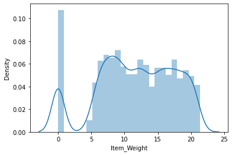

```python
sns.distplot(sales["Item_Weight"])
plt.show()
```

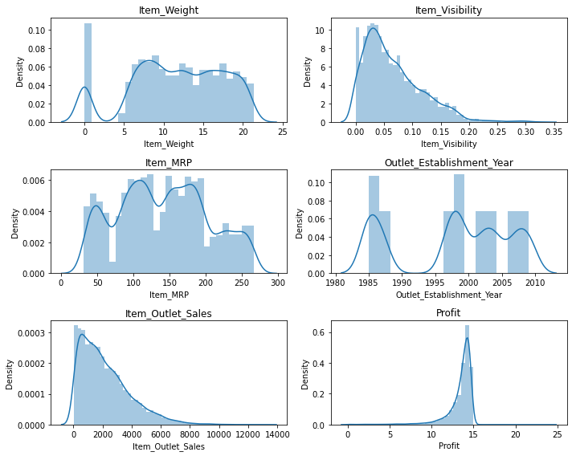

```python
# Univariate Analysis (numeric) - histogram , distribution

plt.figure(figsize=(10,8))

a = 3
b = 2
c = 1
for i in num_cols:
    plt.subplot(a,b,c)
    sns.distplot(sales[i])
    c+=1
    plt.title(i)

plt.tight_layout()
plt.show()
```

# Skewness

It is a measure of the asymmetry of the distribution of data.

It is of three types:

1. Symmetrical (No Skew)
2. Positive Skew (Right-Skewed)
3. Negative Skew (Left-Skewed)

# 1. Symmetrical : Mean ≈ Median ≈ Mode

- The data is evenly distributed around the center.
- A perfect bell shaped curvev! (Balanced on both sides)

# 2. Positive Skew : Mean > Median > Mode

- Tail on the right side is longer.
- Data has a few very large values pulling the mean up.
- Most data is on the left, with a long tail to the right.

# 3. Negative Skew: Mean < Median < Mode

- Tail on the left side is longer.
- Data has a few very small values pulling the mean down.
- Most data is on the right, with a long tail to the left.

| **Skewness Range** | **Interpretation** | **Skew Type** |
| --- | --- | --- |
| **-0.5 to +0.5** | **Approximately symmetric** | Not significantly skewed |
| **-1 to -0.5** or **0.5 to 1** | **Moderately skewed** | Slight left or right skew |
| **Less than -1** or **greater than +1** | **Highly skewed** | Strong left or right skew |

```python
sales[num_cols].skew()
```

```
Item_Weight                 -0.352215
Item_Visibility              1.167091
Item_MRP                     0.127390
Outlet_Establishment_Year   -0.396641
Item_Outlet_Sales            1.177531
Profit                      -3.379808
dtype: float64
```

# Kurtosis

Defines the shape and according to shape it defines the data. How heavy or light the tails are compared to a normal distribution.

It is of three types:

1. Leptokurtic (High Kurtosis)
2. Mesokurtic (Normal)
3. Platykurtic (Low Kurtosis)

# 1. Leptokurtic (Thin)

- Kurtosis > 3 (or Excess > 0)
- Tails are heavy → more outliers.
- Sharp peak.

# 2. Mesokurtic

- Kurtosis ≈ 3 (or 0 if excess kurtosis is used)
- Tails and peak are similar to the normal distribution.

# 3. Platykurtic (Thick/flat)

- Kurtosis < 3 (or Excess < 0)
- Tails are light → fewer outliers.
- Flat peak.

| **Kurtosis Type** | **Kurtosis Value** | **Tails** | **Outliers** | **Shape** |
| --- | --- | --- | --- | --- |
| Mesokurtic | ≈ 3 (Excess = 0) | Normal | Moderate | Normal bell curve |
| Leptokurtic | > 3 (Excess > 0) | Heavy | More (high risk) | Tall & narrow |
| Platykurtic | < 3 (Excess < 0) | Light | Fewer | Flat & wide |

```python
sales[num_cols].kurt()
```

```
Item_Weight                  -0.613755
Item_Visibility               1.679445
Item_MRP                     -0.887901
Outlet_Establishment_Year    -1.205694
Item_Outlet_Sales             1.615877
Profit                       16.965881
dtype: float64
```

```python
# Selecting only categorical data type

cat_cols = sales.select_dtypes(include = "object").columns
cat_cols
```

```
Index(['Item_Identifier', 'Item_Fat_Content', 'Item_Type', 'Outlet_Identifier',
       'Outlet_Size', 'Outlet_Location_Type', 'Outlet_Type'],
      dtype='object')
```

```python
cat_cols = ['Item_Fat_Content', 'Item_Type', 'Outlet_Identifier',
       'Outlet_Size', 'Outlet_Location_Type', 'Outlet_Type']
cat_cols
```

```
['Item_Fat_Content',
 'Item_Type',
 'Outlet_Identifier',
 'Outlet_Size',
 'Outlet_Location_Type',
 'Outlet_Type']
```

```python
sales["Item_Identifier"].nunique()
```

```
1559
```

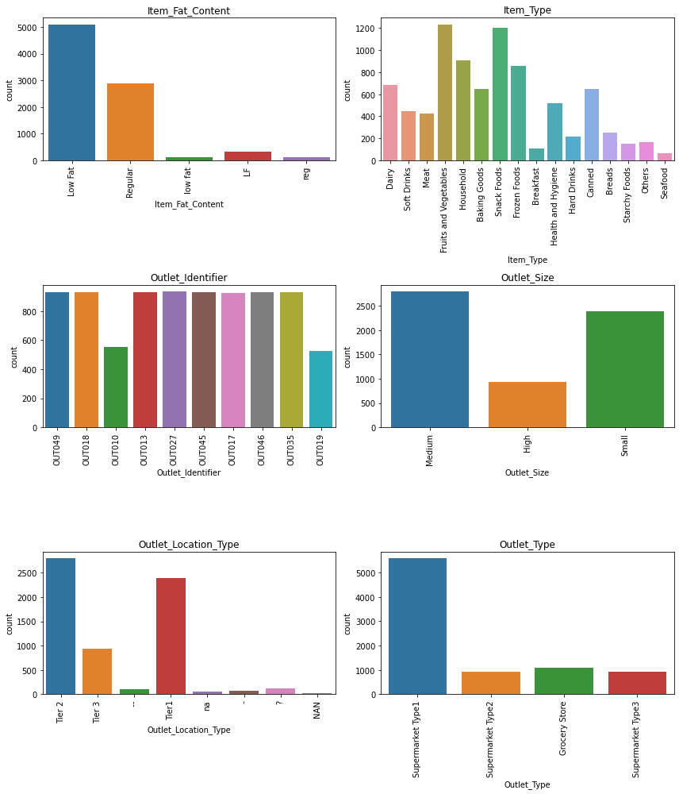

```python
# Univariate Analysis (Categorical columns) - countplot

plt.figure(figsize=(12,14))

c = 1
for i in cat_cols:
    plt.subplot(3,2,c)
    sns.countplot(x = sales[i], data=sales)
    c+=1
    plt.title(i)
    plt.xticks(rotation=90)

plt.tight_layout()
plt.show()
```

##### Findings

- Plotting numeric columns to check their shape, skewness and other errors using histogram (kde).
  - We can see **Item Weight** have *Incorrect Values* (Yet to confirm).
  - **Item Visibility, Item Outlet Sales** and **Profit** seemed to be *skewed* and *shape* is also *not normal*.
- Plotting categorical columns to check the frequency and irregularities in categories using countplot.
  - **Item Fat Content** and **Outlet Location Type** have *irregular Categories*.

# Bivariate analysis (Predictor vs Target)

Bivariate analysis is the process of exploring the relationship between two variables in a dataset — typically one predictor and one target.

1. Num vs Num - scatterplot, lineplot, regplot
2. Cat vs Num - boxplot, violinplot, barplot, swarmplot
3. Cat vs Cat - countplot, frequency, stacked bar, heatmap

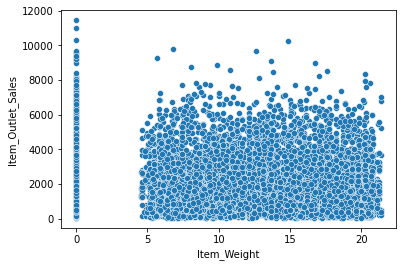

```python
sns.scatterplot(x = "Item_Weight", y = "Item_Outlet_Sales", data=sales)
plt.show()
```

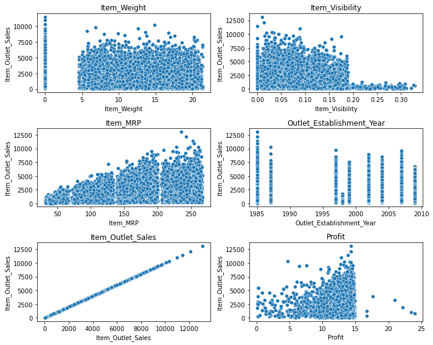

```python
# Num vs Num

plt.figure(figsize=(10,8))

c = 1
for i in num_cols:
    plt.subplot(3,2,c)
    sns.scatterplot(x = sales[i], y = "Item_Outlet_Sales", data=sales)
    c+=1
    plt.title(i)

plt.tight_layout()
plt.show()
```

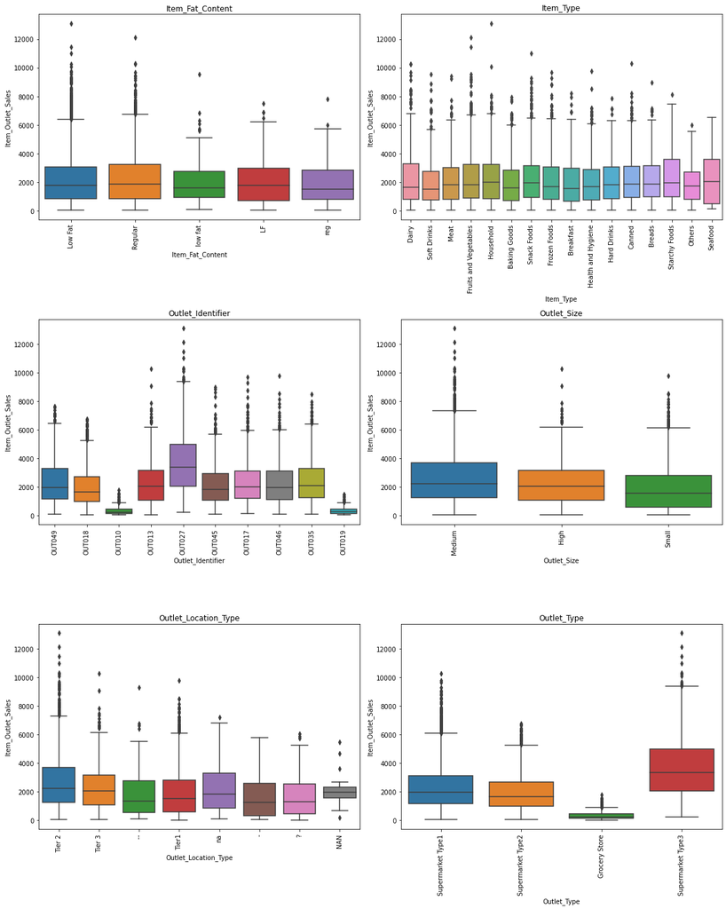

```python
# Cat vs Num - Boxplot (x= category,y=numeric, data=dataframe)

plt.figure(figsize=(16,20))

c = 1
for i in cat_cols:
    plt.subplot(3,2,c)
    sns.boxplot(x = sales[i], y = "Item_Outlet_Sales", data=sales)
#     sns.barplot(x = sales[i], y = "Item_Outlet_Sales", data=sales)
#     sns.violinplot(x = sales[i], y = "Item_Outlet_Sales", data=sales)
#     sns.swarmplot(x = sales[i], y = "Item_Outlet_Sales", data=sales)
    c+=1
    plt.title(i)
    plt.xticks(rotation=90)

plt.tight_layout()
plt.show()
```

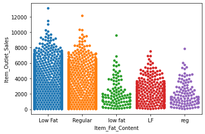

```python
sns.swarmplot(x='Item_Fat_Content',y='Item_Outlet_Sales',data=sales)
plt.show()
```

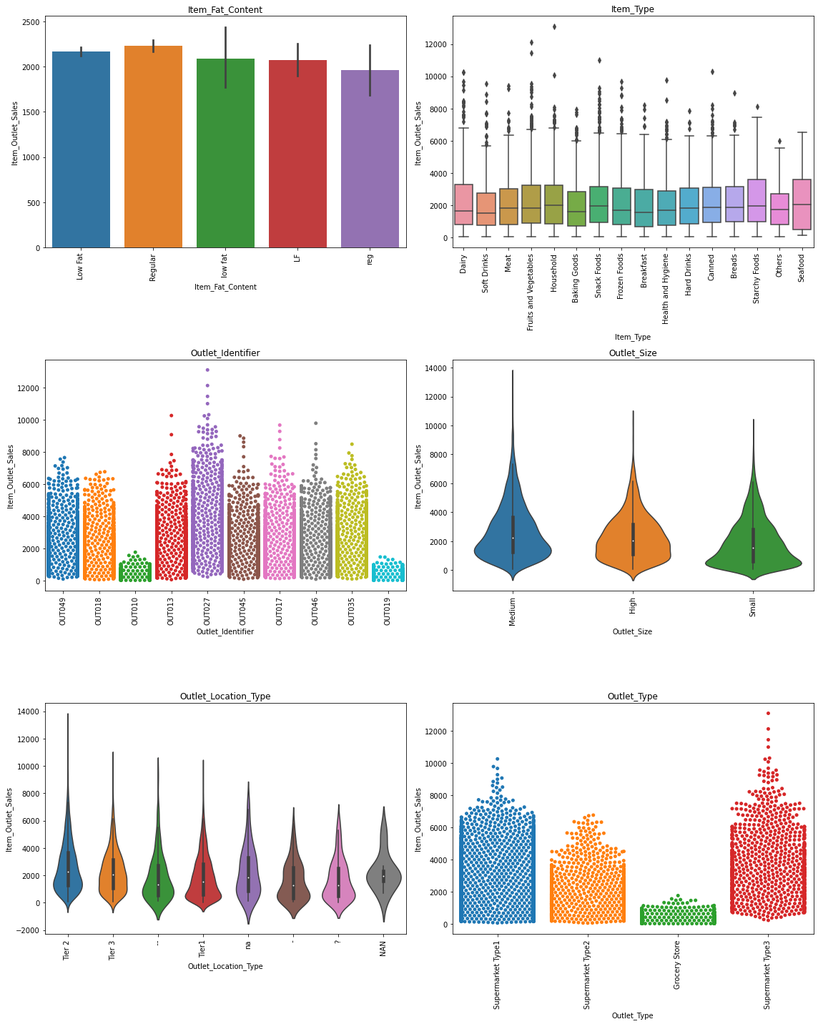

```python
 # Trying different plots with different data item

plt.figure(figsize=(16, 20))

for c, i in enumerate(cat_cols):
    plt.subplot(3, 2, c+1)

    if c == 0:
        sns.barplot(x=sales[i], y="Item_Outlet_Sales", data=sales)
    elif c == 1:
        sns.boxplot(x=sales[i], y="Item_Outlet_Sales", data=sales)
    elif c == 2:
        sns.swarmplot(x=sales[i], y="Item_Outlet_Sales", data=sales)
    elif c == 3:
        sns.violinplot(x=sales[i], y="Item_Outlet_Sales", data=sales)
    elif c == 4:
        sns.violinplot(x=sales[i], y="Item_Outlet_Sales", data=sales)
    elif c == 5:
        sns.swarmplot(x=sales[i], y="Item_Outlet_Sales", data=sales)

    plt.title(i)
    plt.xticks(rotation=90)

plt.tight_layout()
plt.show()
```

# Correlation

It measures the linear relationship or strength and direction of the relationship between two numerical variables. It ranges from:

| **r Value** | **Interpretation** |
| --- | --- |
| `+1` | Perfect **positive** correlation |
| `0` | **No** correlation |
| `-1` | Perfect **negative** correlation |

1. Positive Correlation : As X increases, Y also increases
2. Negative Correlation : As X increases, Y decreases
3. No Correlation : No clear relationship between X and Y

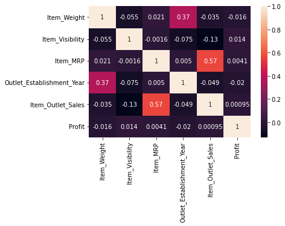

```python
# correlation

sns.heatmap(sales[num_cols].corr(),annot=True)
plt.show()
```

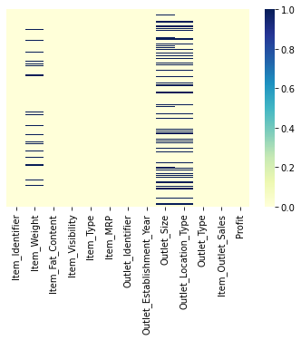

```python
# Visualizimg Null Values

sns.heatmap(sales.isnull(), yticklabels=False, annot = False, cmap="YlGnBu")
plt.show()
```

##### Findings

```python
# Missing values

sales.isnull().sum()
```

```
Item_Identifier                 0
Item_Weight                   749
Item_Fat_Content                0
Item_Visibility                 0
Item_Type                       0
Item_MRP                        0
Outlet_Identifier               0
Outlet_Establishment_Year       0
Outlet_Size                  2410
Outlet_Location_Type         2050
Outlet_Type                     0
Item_Outlet_Sales               0
Profit                          0
dtype: int64
```

```python
# Percentage of Null Values

sales.isnull().mean()*100
```

```
Item_Identifier               0.000000
Item_Weight                   8.787985
Item_Fat_Content              0.000000
Item_Visibility               0.000000
Item_Type                     0.000000
Item_MRP                      0.000000
Outlet_Identifier             0.000000
Outlet_Establishment_Year     0.000000
Outlet_Size                  28.276428
Outlet_Location_Type         24.052564
Outlet_Type                   0.000000
Item_Outlet_Sales             0.000000
Profit                        0.000000
dtype: float64
```

```python
# loc :
# loc[] is a label-based indexer in pandas.
# It is used to access a group of rows and columns by labels or a boolean array.
```

```python
# Give all rows in the sales DataFrame where the Item_Weight is missing.

sales.loc[sales["Item_Weight"].isnull()]
```

|  | Item_Identifier | Item_Weight | Item_Fat_Content | Item_Visibility | Item_Type | Item_MRP | Outlet_Identifier | Outlet_Establishment_Year | Outlet_Size | Outlet_Location_Type | Outlet_Type | Item_Outlet_Sales | Profit |
| --- | --- | --- | --- | --- | --- | --- | --- | --- | --- | --- | --- | --- | --- |
| 7 | FDP10 | NaN | Low Fat | 0.127470 | Snack Foods | 107.8 | OUT027 | 1985 | Medium | Tier 2 | Supermarket Type3 | 4022.7636 | 13.3 |
| 18 | DRI11 | NaN | Low Fat | 0.034238 | Hard Drinks | 113.3 | OUT027 | 1985 | Medium | Tier 2 | Supermarket Type3 | 2303.6680 | 14.4 |
| 21 | FDW12 | NaN | Regular | 0.035400 | Baking Goods | 144.5 | OUT027 | 1985 | Medium | Tier 2 | Supermarket Type3 | 4064.0432 | 14.7 |
| 23 | FDC37 | NaN | Low Fat | 0.057557 | Baking Goods | 107.7 | OUT019 | 1985 | Small | Tier1 | Grocery Store | 214.3876 | 13.7 |
| 29 | FDC14 | NaN | Regular | 0.072222 | Canned | 43.6 | OUT019 | 1985 | Small | Tier1 | Grocery Store | 125.8362 | 10.8 |
| ... | ... | ... | ... | ... | ... | ... | ... | ... | ... | ... | ... | ... | ... |
| 8404 | DRH39 | NaN | low fat | 0.000000 | Dairy | 76.0 | OUT019 | 1985 | Small | Tier1 | Grocery Store | 153.1340 | 14.6 |
| 8405 | FDB09 | NaN | Low Fat | 0.100493 | Fruits and Vegetables | 123.1 | OUT019 | 1985 | Small | Tier1 | Grocery Store | 124.5046 | 11.3 |
| 8422 | FDD08 | NaN | Low Fat | 0.035183 | Fruits and Vegetables | 37.9 | OUT027 | 1985 | Medium | Tier 2 | Supermarket Type3 | 417.4566 | 13.9 |
| 8435 | FDT48 | NaN | Low Fat | 0.000000 | Baking Goods | 196.5 | OUT027 | 1985 | Medium | Tier 2 | Supermarket Type3 | 793.6336 | 14.6 |
| 8442 | FDX40 | NaN | Low Fat | 0.173324 | Frozen Foods | 39.9 | OUT019 | 1985 | Small | Tier1 | Grocery Store | 38.6164 | 12.9 |

749 rows × 13 columns

```python
sales["Item_Weight"].mean()
```

```
11.67673977360451
```

```python
sales["Item_Weight"].median()
```

```
11.8
```

```python
# Grouping by Item_Identifier and selecting only Item_Weight column as we are working on that at present

sales.groupby("Item_Identifier")["Item_Weight"].mean()
```

```
Item_Identifier
DRA12    11.600000
DRA24    16.125000
DRA59     7.088571
DRB01     4.926667
DRB13     6.115000
           ...
NCZ30     6.590000
NCZ41    19.850000
NCZ42    10.500000
NCZ53     7.680000
NCZ54    12.208333
Name: Item_Weight, Length: 1559, dtype: float64
```

```python
# Replacing null values with the mean of grouped columns to Item_weight

val1 = sales.groupby("Item_Identifier")["Item_Weight"].transform(lambda x: x.fillna(x.mean()))
val1
```

```
0        9.300
1        5.920
2       17.500
3       19.200
4        8.930
         ...
8518     6.865
8519     8.380
8520    10.600
8521     7.210
8522    14.800
Name: Item_Weight, Length: 8523, dtype: float64
```

```python
# Replacing the original column by appplying the treated data to actual dataset

sales["Item_Weight"] = val1
```

```python
sales.head()
```

|  | Item_Identifier | Item_Weight | Item_Fat_Content | Item_Visibility | Item_Type | Item_MRP | Outlet_Identifier | Outlet_Establishment_Year | Outlet_Size | Outlet_Location_Type | Outlet_Type | Item_Outlet_Sales | Profit |
| --- | --- | --- | --- | --- | --- | --- | --- | --- | --- | --- | --- | --- | --- |
| 0 | FDA15 | 9.30 | Low Fat | 0.016047 | Dairy | 249.8 | OUT049 | 1999 | Medium | Tier 2 | Supermarket Type1 | 3735.1380 | 11.5 |
| 1 | DRC01 | 5.92 | Regular | 0.019278 | Soft Drinks | 48.3 | OUT018 | 2009 | Medium | Tier 2 | Supermarket Type2 | 443.4228 | 14.3 |
| 2 | FDN15 | 17.50 | Low Fat | 0.016760 | Meat | 141.6 | OUT049 | 1999 | Medium | Tier 2 | Supermarket Type1 | 2097.2700 | 14.5 |
| 3 | FDX07 | 19.20 | Regular | 0.000000 | Fruits and Vegetables | 182.1 | OUT010 | 1998 | NaN | NaN | Grocery Store | 732.3800 | 13.6 |
| 4 | NCD19 | 8.93 | Low Fat | 0.000000 | Household | 53.9 | OUT013 | 1987 | High | Tier 3 | Supermarket Type1 | 994.7052 | 14.1 |

```python
sales[sales["Item_Weight"].isnull()]
```

|  | Item_Identifier | Item_Weight | Item_Fat_Content | Item_Visibility | Item_Type | Item_MRP | Outlet_Identifier | Outlet_Establishment_Year | Outlet_Size | Outlet_Location_Type | Outlet_Type | Item_Outlet_Sales | Profit |
| --- | --- | --- | --- | --- | --- | --- | --- | --- | --- | --- | --- | --- | --- |
| 1922 | FDK57 | NaN | Low Fat | 0.079904 | Snack Foods | 120.0 | OUT027 | 1985 | Medium | Tier 2 | Supermarket Type3 | 4434.2280 | 14.5 |
| 5022 | FDQ60 | NaN | Regular | 0.191501 | Baking Goods | 121.2 | OUT019 | 1985 | Small | Tier1 | Grocery Store | 120.5098 | 12.3 |

```python
# Filling the left values
```

```python
val2 = sales.loc[(sales["Item_Fat_Content"] == "Low Fat") & (sales["Item_Type"] == "Snack Foods"), "Item_Weight"].mean()
val2
```

```
12.46708841688852
```

```python
val3 = sales.loc[(sales["Item_Fat_Content"] == "Regular") & (sales["Item_Type"] == "Baking Goods"), "Item_Weight"].mean()
val3
```

```
11.1037393442623
```

```python
# Filling the missing data values with mean
```

```python
sales.loc[sales["Item_Identifier"] == "FDK57", "Item_Weight"] = np.round(val2,2)
sales.loc[sales["Item_Identifier"] == "FDQ60", "Item_Weight"] = np.round(val3,2)
```

```python
sales.loc[sales["Item_Weight"].isnull()]
```

|  | Item_Identifier | Item_Weight | Item_Fat_Content | Item_Visibility | Item_Type | Item_MRP | Outlet_Identifier | Outlet_Establishment_Year | Outlet_Size | Outlet_Location_Type | Outlet_Type | Item_Outlet_Sales | Profit |
| --- | --- | --- | --- | --- | --- | --- | --- | --- | --- | --- | --- | --- | --- |

```python
# checking

sales.isnull().sum()
```

```
Item_Identifier                 0
Item_Weight                     0
Item_Fat_Content                0
Item_Visibility                 0
Item_Type                       0
Item_MRP                        0
Outlet_Identifier               0
Outlet_Establishment_Year       0
Outlet_Size                  2410
Outlet_Location_Type         2050
Outlet_Type                     0
Item_Outlet_Sales               0
Profit                          0
dtype: int64
```

```python
# For Category

sales['Outlet_Size'].mode()[0]
```

```
'Medium'
```

```python
sales['Outlet_Size'] = sales['Outlet_Size'].fillna(sales['Outlet_Size'].mode()[0])
```

```python
sales['Outlet_Location_Type'].mode()
```

```
0    Tier 2
Name: Outlet_Location_Type, dtype: object
```

```python
sales['Outlet_Location_Type'] = sales['Outlet_Location_Type'].fillna(sales['Outlet_Location_Type'].mode()[0])
```

```python
# Re-checking

sales.isnull().sum()
```

```
Item_Identifier              0
Item_Weight                  0
Item_Fat_Content             0
Item_Visibility              0
Item_Type                    0
Item_MRP                     0
Outlet_Identifier            0
Outlet_Establishment_Year    0
Outlet_Size                  0
Outlet_Location_Type         0
Outlet_Type                  0
Item_Outlet_Sales            0
Profit                       0
dtype: int64
```

##### Findings

- Using Heatmap to visually see which columns have null values andd also using percentage to see if they are treatable.
  - Here, **Item Weight, Outlet_Size** and **Outlet_Location_Type** have null values less than 50% so we can treat them.
  - Grouping **Item Weight** with **Item Identifiers** and applying *mean* and imputing the values in place of missing values.
  - Rechecking and manually imputing values for the two values which got overlooked by *mean* based on their **Item Fat Content** and **Item Type**.
  - For **Outlet Size** and **Outlet Location Type**, we are using *mode* to fill the null values.
- Finally rechecking the whole data if any null value is present or not.

# Feature Engineering

It is the process of creating, transforming, or selecting features (columns) in a dataset to improve the performance of the machine learning model or gain better insights in EDA.

1. Handling Missing Values: Fill missing values with mean or group mean
2. Encoding Categorical Variables: Label Encoding and One-Hot Encoding
3. Creating New Features: uncover hidden patterns, improve model performance, and bring domain knowledge into the dataset
4. Binning: Group into ranges as Low, Medium, High
5. Feature Transformation: Log-transform to reduce skewness
6. Date Feature Extraction (if you have date column): Extract year, month, day from a datetime column

```python
sales.head()
```

|  | Item_Identifier | Item_Weight | Item_Fat_Content | Item_Visibility | Item_Type | Item_MRP | Outlet_Identifier | Outlet_Establishment_Year | Outlet_Size | Outlet_Location_Type | Outlet_Type | Item_Outlet_Sales | Profit |
| --- | --- | --- | --- | --- | --- | --- | --- | --- | --- | --- | --- | --- | --- |
| 0 | FDA15 | 9.30 | Low Fat | 0.016047 | Dairy | 249.8 | OUT049 | 1999 | Medium | Tier 2 | Supermarket Type1 | 3735.1380 | 11.5 |
| 1 | DRC01 | 5.92 | Regular | 0.019278 | Soft Drinks | 48.3 | OUT018 | 2009 | Medium | Tier 2 | Supermarket Type2 | 443.4228 | 14.3 |
| 2 | FDN15 | 17.50 | Low Fat | 0.016760 | Meat | 141.6 | OUT049 | 1999 | Medium | Tier 2 | Supermarket Type1 | 2097.2700 | 14.5 |
| 3 | FDX07 | 19.20 | Regular | 0.000000 | Fruits and Vegetables | 182.1 | OUT010 | 1998 | Medium | Tier 2 | Grocery Store | 732.3800 | 13.6 |
| 4 | NCD19 | 8.93 | Low Fat | 0.000000 | Household | 53.9 | OUT013 | 1987 | High | Tier 3 | Supermarket Type1 | 994.7052 | 14.1 |

```python
sales["Item_Identifier"].nunique()
```

```
1559
```

```python
# Creating new labels from existing one
```

```python
sales['Item_Identifier'][0][:2]
```

```
'FD'
```

```python
items = []
for i in sales["Item_Identifier"]:
    items.append(i[:2])
#print(items)
```

```python
# Findig position of item_identifier
position = sales.columns.get_loc("Item_Identifier") + 1
position
```

```
1
```

```python
sales.insert(position, "Item_IDs", items) # Inserting at the specific position
```

```python
sales.rename(columns={"Item_IDs" : "Item_Codes"}, inplace=True)  # Renaming
```

```python
sales.head()
```

|  | Item_Identifier | Item_Codes | Item_Weight | Item_Fat_Content | Item_Visibility | Item_Type | Item_MRP | Outlet_Identifier | Outlet_Establishment_Year | Outlet_Size | Outlet_Location_Type | Outlet_Type | Item_Outlet_Sales | Profit |
| --- | --- | --- | --- | --- | --- | --- | --- | --- | --- | --- | --- | --- | --- | --- |
| 0 | FDA15 | FD | 9.30 | Low Fat | 0.016047 | Dairy | 249.8 | OUT049 | 1999 | Medium | Tier 2 | Supermarket Type1 | 3735.1380 | 11.5 |
| 1 | DRC01 | DR | 5.92 | Regular | 0.019278 | Soft Drinks | 48.3 | OUT018 | 2009 | Medium | Tier 2 | Supermarket Type2 | 443.4228 | 14.3 |
| 2 | FDN15 | FD | 17.50 | Low Fat | 0.016760 | Meat | 141.6 | OUT049 | 1999 | Medium | Tier 2 | Supermarket Type1 | 2097.2700 | 14.5 |
| 3 | FDX07 | FD | 19.20 | Regular | 0.000000 | Fruits and Vegetables | 182.1 | OUT010 | 1998 | Medium | Tier 2 | Grocery Store | 732.3800 | 13.6 |
| 4 | NCD19 | NC | 8.93 | Low Fat | 0.000000 | Household | 53.9 | OUT013 | 1987 | High | Tier 3 | Supermarket Type1 | 994.7052 | 14.1 |

```python
sales["Item_Fat_Content"].unique()
```

```
array(['Low Fat', 'Regular', 'low fat', 'LF', 'reg'], dtype=object)
```

```python
# Replacing Unnecessary Values

sales.replace(to_replace=['Low Fat', 'Regular', 'low fat', 'LF', 'reg'],
              value=['Low Fat', 'Regular', 'Low Fat', 'Low Fat', 'Regular'], inplace=True)
```

```python
# Creating New Category for non edible items

sales.loc[sales["Item_Codes"] == "NC", "Item_Fat_Content"] = "Non-Consumable"
```

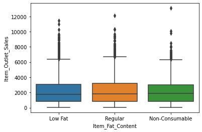

```python
sns.boxplot(x = "Item_Fat_Content", y="Item_Outlet_Sales", data=sales)
plt.show()
```

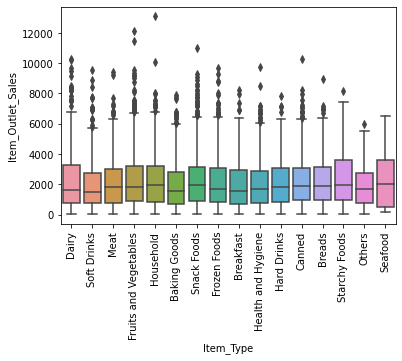

```python
sns.boxplot(x = "Item_Type", y = "Item_Outlet_Sales", data=sales)
plt.xticks(rotation=90)
plt.show()
```

```python
# For Item Type

sales["Item_Type"].unique()
```

```
array(['Dairy', 'Soft Drinks', 'Meat', 'Fruits and Vegetables',
       'Household', 'Baking Goods', 'Snack Foods', 'Frozen Foods',
       'Breakfast', 'Health and Hygiene', 'Hard Drinks', 'Canned',
       'Breads', 'Starchy Foods', 'Others', 'Seafood'], dtype=object)
```

```python
# Creating new labels from existing one

perishables = ['Dairy','Meat','Fruits and Vegetables','Breakfast','Breads','Starchy Foods', 'Seafood' ]
perishables
```

```
['Dairy',
 'Meat',
 'Fruits and Vegetables',
 'Breakfast',
 'Breads',
 'Starchy Foods',
 'Seafood']
```

```python
def perish(x):
    if x in perishables:
        return "Perishables"
    else:
        return "Non-Perishables"
```

```python
# Using apply function to create new category

sales["Item_Type"] = sales["Item_Type"].apply(perish)
```

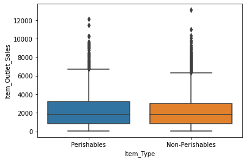

```python
sns.boxplot(x = "Item_Type", y = "Item_Outlet_Sales", data = sales)
plt.show()
```

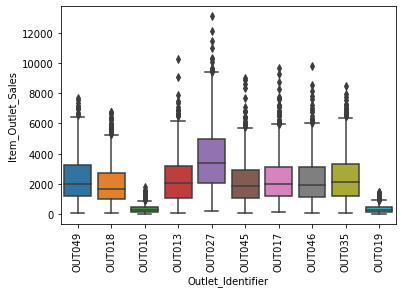

```python
# For Outlet Identifier

sns.boxplot(x="Outlet_Identifier", y = "Item_Outlet_Sales", data=sales)
plt.xticks(rotation = 90)
plt.show()
```

```python
sales.groupby("Outlet_Identifier")["Item_Outlet_Sales"].mean()  # analysis
```

```
Outlet_Identifier
OUT010     339.351662
OUT013    2298.995256
OUT017    2340.675263
OUT018    1995.498739
OUT019     340.329723
OUT027    3694.038558
OUT035    2438.841866
OUT045    2192.384798
OUT046    2277.844267
OUT049    2348.354635
Name: Item_Outlet_Sales, dtype: float64
```

```python
x = (sales.groupby("Outlet_Identifier")["Item_Outlet_Sales"].mean()) > 2400  # analysis
x[x]                                                                         # Returns true value only
```

```
Outlet_Identifier
OUT027    True
OUT035    True
Name: Item_Outlet_Sales, dtype: bool
```

```python
x = (sales.groupby("Outlet_Identifier")["Item_Outlet_Sales"].mean()) < 1200  # analysis
x[x]                                                                         # Returns true value only
```

```
Outlet_Identifier
OUT010    True
OUT019    True
Name: Item_Outlet_Sales, dtype: bool
```

```python
# Creating new labels from existing one

High = ["OUT027", "OUT035"]
Low = ["OUT010", "OUT019"]
```

```python
def out_id(x):
    if x in High:
        return "High"
    if x in Low:
        return "Low"
    else:
        return "Medium"
```

```python
sales["Outlet_Identifier"] = sales["Outlet_Identifier"].apply(out_id)
```

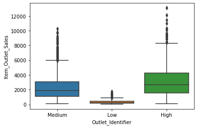

```python
sns.boxplot(x="Outlet_Identifier", y = "Item_Outlet_Sales", data=sales)
plt.show()
```

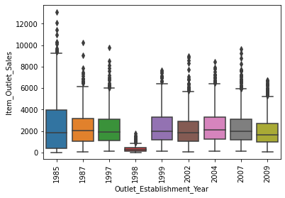

```python
sns.boxplot(x = "Outlet_Establishment_Year", y = "Item_Outlet_Sales", data=sales)
plt.xticks(rotation=90)
plt.show()
```

```python
sales["Outlet_Size"].unique()
```

```
array(['Medium', 'High', 'Small'], dtype=object)
```

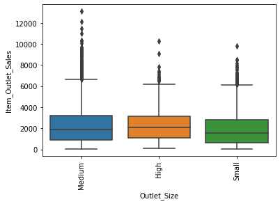

```python
sns.boxplot(x = "Outlet_Size", y = "Item_Outlet_Sales", data=sales)
plt.xticks(rotation=90)
plt.show()
```

```python
sales["Outlet_Location_Type"].unique()
```

```
array(['Tier 2', 'Tier 3', '  --', 'Tier1', 'na', '  -', '?', 'NAN'],
      dtype=object)
```

```python
# Replacing Unnecessary Values

sales["Outlet_Location_Type"].replace(to_replace= ['nan', '  --', 'na', '  -', '?', 'NAN' ],
                                      value=["Missing"]*6, inplace=True)
```

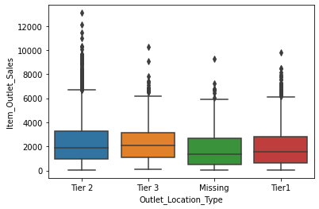

```python
sns.boxplot( x = "Outlet_Location_Type", y = "Item_Outlet_Sales",data= sales)
plt.show()
```

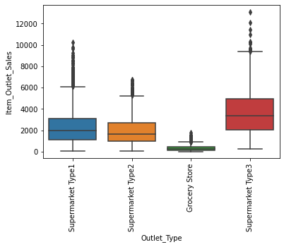

```python
sns.boxplot( x = "Outlet_Type", y = "Item_Outlet_Sales",data= sales)
plt.xticks(rotation = 90)
plt.show()
```

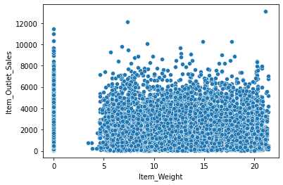

```python
sns.scatterplot(x = "Item_Weight", y = "Item_Outlet_Sales", data=sales)
plt.show()
```

```python
# Correcting incorrect values
weights = np.round(sales.groupby("Item_Identifier")["Item_Weight"].mean(),2).to_dict()
weights
```

```
{'DRA12': 11.6,
 'DRA24': 16.12,
 'DRA59': 7.09,
 'DRB01': 4.93,
 'DRB13': 6.12,
 'DRB24': 8.78,
 'DRB25': 12.3,
 'DRB48': 14.36,
 'DRC01': 5.92,
 'DRC12': 17.85,
 'DRC13': 8.26,
 'DRC24': 17.85,
 'DRC25': 5.73,
 'DRC27': 13.8,
 'DRC36': 13.0,
 'DRC49': 8.67,
 'DRD01': 12.1,
 'DRD12': 6.96,
 'DRD13': 15.0,
 'DRD15': 9.09,
 'DRD24': 13.85,
 'DRD25': 5.26,
 'DRD27': 15.0,
 'DRD37': 9.8,
 'DRD49': 9.9,
 'DRD60': 15.7,
 'DRE01': 10.1,
 'DRE03': 19.6,
 'DRE12': 4.59,
 'DRE13': 6.28,
 'DRE15': 10.68,
 'DRE25': 12.28,
 'DRE27': 11.85,
 'DRE37': 13.5,
 'DRE48': 8.43,
 'DRE49': 20.75,
 'DRE60': 7.83,
 'DRF01': 4.24,
 'DRF03': 19.1,
 'DRF13': 12.1,
```

[output cut: 946 more lines]

```
 'FDU24': 5.42,
 'FDU25': 10.59,
 'FDU26': 13.92,
 'FDU27': 14.88,
 'FDU28': 14.4,
 'FDU31': 10.5,
 'FDU32': 7.03,
 'FDU33': 7.63,
 'FDU34': 18.25,
 'FDU35': 6.44,
 'FDU36': 5.12,
 'FDU37': 7.6,
 'FDU38': 9.0,
 'FDU39': 18.85,
 ...}
```

```python
sales["Item_Weight"] = sales["Item_Identifier"].map(weights)   # Mapping correct values
```

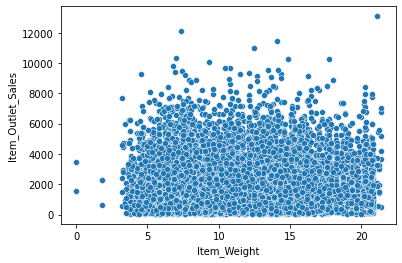

```python
sns.scatterplot(x = "Item_Weight", y = "Item_Outlet_Sales", data=sales)
plt.show()
```

```python
# Rechecking for incorrect values

sales.loc[sales["Item_Weight"] == 0]
```

|  | Item_Identifier | Item_Codes | Item_Weight | Item_Fat_Content | Item_Visibility | Item_Type | Item_MRP | Outlet_Identifier | Outlet_Establishment_Year | Outlet_Size | Outlet_Location_Type | Outlet_Type | Item_Outlet_Sales | Profit |
| --- | --- | --- | --- | --- | --- | --- | --- | --- | --- | --- | --- | --- | --- | --- |
| 927 | FDN52 | FD | 0.0 | Regular | 0.130933 | Non-Perishables | 86.9 | High | 1985 | Medium | Tier 2 | Supermarket Type3 | 1569.9564 | 14.1 |
| 4187 | FDE52 | FD | 0.0 | Regular | 0.029742 | Perishables | 89.0 | High | 1985 | Medium | Tier 2 | Supermarket Type3 | 3453.5046 | 13.9 |

```python
# Imputing values

val4 = sales.loc[(sales["Item_Fat_Content"] == "Regular") & (sales["Item_Identifier"] == "FDN52"), "Item_Weight"].mean()
val4
sales.loc[(sales["Item_Identifier"] == "FDN52"), "Item_Weight"] = np.round(val4,2)
```

```python
# Dropping the other one ( we can also impute the value )

sales = sales.drop(sales[sales["Item_Identifier"] == "FDE52"].index)
```

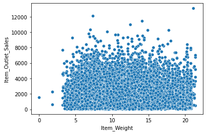

```python
sns.scatterplot(x = "Item_Weight", y = "Item_Outlet_Sales", data=sales)
plt.show()
```

```python
sales.isnull().sum()
```

```
Item_Identifier              0
Item_Codes                   0
Item_Weight                  0
Item_Fat_Content             0
Item_Visibility              0
Item_Type                    0
Item_MRP                     0
Outlet_Identifier            0
Outlet_Establishment_Year    0
Outlet_Size                  0
Outlet_Location_Type         0
Outlet_Type                  0
Item_Outlet_Sales            0
Profit                       0
dtype: int64
```

##### Findings

# Outliers

These are the data points that are significantly different from the rest of the data. They lie far away from the central values and can distort:

1. Averages (mean) : Can pull the average too high or low
2. Standard deviations : Boxplots and histograms look off
3. Machine learning models : Affects regression, clustering, etc.

# How to Detect Outliers

1. IQR Method (Interquartile Range)
2. Z-score Method
3. Percentile-based Capping

| Strategy | Use Case |
| --- | --- |
| **Remove** | If they are errors or rare cases |
| **Cap (Winsorize)** | If you want to limit their influence |
| **Transform** | Use `log`, `sqrt`, etc. to reduce skew |
| **Model-specific handling** | Some models (like tree-based) handle them well |

1. IQR Method (Interquartile Range): Measures the spread of the middle 50% of the data.
- Based on quartiles:
- Q1 (25th percentile)
- Q3 (75th percentile)
- IQR = Q3 - Q1
1. Z-Score Method (Standard Score): Measures how many standard deviations a value is from the mean.
- Based on normal distribution.
- Any data point with a Z-score > 3 or < -3 is considered an outlier.
1. Percentile Method (Winsorization): Capping data at low and high percentiles.
- Doesn’t remove outliers, but replaces them with percentile limits.
- Cap values below the 10th percentile and above the 95th percentile.

| Method | Based On | Detects | Common Thresholds | Action |
| --- | --- | --- | --- | --- |
| **IQR** | Quartiles (Q1, Q3) | Range-based | 1.5 × IQR | Remove or Cap |
| **Z-Score** | Mean & Std Dev | Normal data | Z > 3 or Z < -3 | Remove |
| **Percentile** | Distribution Percentiles | Mild outliers | 5th–95th, 10th–90th, etc. | Cap (Winsorize) |

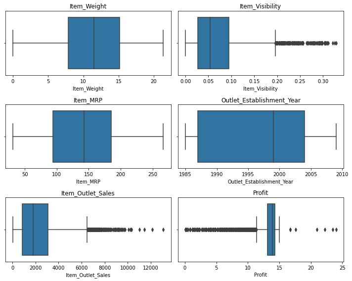

```python
# Outliers treatment

plt.figure(figsize=(10,8))

c = 1
for i in num_cols:
    plt.subplot(3,2,c)
    sns.boxplot(x = sales[i], data=sales)
    c+=1
    plt.title(i)
    #plt.xticks(rotation=90)

plt.tight_layout()
plt.show()
```

```python
# Capping Outliers with percentiles

ll,ul = np.percentile(sales["Item_Visibility"],[10,95])
sales.loc[sales["Item_Visibility"]>ul, "Item_Visibility"]=ul
sales.loc[sales["Item_Visibility"]<ll,"Item_Visibility"]=ll
```

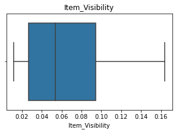

```python
# Visualising treated outliers

plt.figure(figsize=(5,3))
sns.boxplot(x = sales['Item_Visibility'], data=sales)
plt.title("Item_Visibility")
plt.show()
```

```python
# Outlier Trement for Profit


'''
from scipy.stats.mstats import winsorize

sales["Profit"] = winsorize(sales["Profit"], limits=[0.10, 0.10])  # Caps lowest & highest 10%
'''


# using winsorize but can also use quantile one

'''

lb, ub  = sales["Profit"].quantile([0.05,0.95])
sales["Profit_2"] = sales["Profit"].clip(lower = lb, upper = ub)

or

for i in num_cols:
    #q1,q3 = np.quantile(data[i],[0.25,0.75])
    #iqr = q3-q1
    #ul = q3+(1.5*iqr)
    #ll = q1-(1.5*iqr)
    ll,ul = np.quantile(sales[i],[0.10,0.95])
    sales.loc[sales[i]>ul,i]=ul
    sales.loc[sales[i]<ll,i]=ll

'''

# commenting just to prevent re application
```

# Yeo-Johnson Transformation

It is a power transformation technique used to make data more normally distributed (reduces skewness) which is useful for improving performance of machine learning models. It is similar to Box-Cox, but with one key advantage: 🟢 Yeo-Johnson works with both positive and negative values, 🔴 while Box-Cox only works with positive values.

📌 Why Use It?

- Handle skewed data
- Improve normality (important for linear models, regression, etc.)
- Reduce the impact of outliers
- Stabilize variance

🧠 When to Use Yeo-Johnson?

- If data is not normally distributed
- If features contain negative numbers.
- Before applying models that assume normality (like linear regression, logistic regression, etc.)

```python
# Importing Yeo - Johnson

from sklearn.preprocessing import PowerTransformer
pt = PowerTransformer(method='yeo-johnson')
```

```python
# Outlier Treatment for sales

sales["Item_Outlet_Sales"] = pt.fit_transform(sales[["Item_Outlet_Sales"]])
```

| λ Value | Transformation Effect |
| --- | --- |
| λ = 1 | No change (identity transformation) |
| λ = 0 | Log transformation |
| λ < 1 | Compresses large values more (reduces skew) |
| λ > 1 | Expands values (useful if data is left-skewed) |
| λ = 2 | Special case for Yeo-Johnson (negative log) |

```python
# Checking for remaining one

q1 = sales["Item_Outlet_Sales"].quantile(0.25)
q3 = sales["Item_Outlet_Sales"].quantile(0.75)
iqr = q3 - q1

outliers = sales[(sales["Item_Outlet_Sales"] < q1 - 1.5*iqr) | (sales["Item_Outlet_Sales"] > q3 + 1.5*iqr)]
outliers
```

[output not shown]

186 rows × 14 columns

```python
# Removing Them

sales = sales[~sales.index.isin(outliers.index)]
```

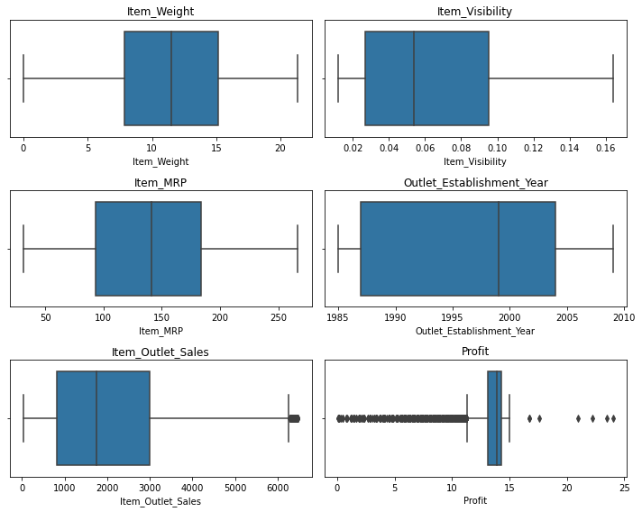

```python
# Rechecking

plt.figure(figsize=(10,8))
c=1

for i in num_cols:
    plt.subplot(3,2,c)
    sns.boxplot(x = sales[i], data = sales)
    c+=1
    plt.title(i)
plt.tight_layout()
plt.show()
```

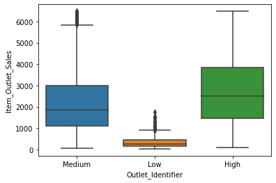

```python
sns.boxplot(x="Outlet_Identifier", y = "Item_Outlet_Sales", data=sales)
plt.show()
```

```python
# Treating for Outlet Identifier

s = sales.groupby("Outlet_Identifier")["Item_Outlet_Sales"]

qq1 = s.transform(lambda x : x.quantile(0.25))
qq3 = s.transform(lambda x : x.quantile(0.75))
iqrr = qq3 - qq1

outlierss = (sales["Item_Outlet_Sales"] < qq1 - 1.5 * iqrr) | (sales["Item_Outlet_Sales"] > qq3 + 1.5 * iqrr)
sales[outlierss].head()
```

|  | Item_Identifier | Item_Codes | Item_Weight | Item_Fat_Content | Item_Visibility | Item_Type | Item_MRP | Outlet_Identifier | Outlet_Establishment_Year | Outlet_Size | Outlet_Location_Type | Outlet_Type | Item_Outlet_Sales | Profit |
| --- | --- | --- | --- | --- | --- | --- | --- | --- | --- | --- | --- | --- | --- | --- |
| 55 | FDK21 | FD | 7.9 | Low Fat | 0.012039 | Non-Perishables | 249.0 | Medium | 2009 | Medium | Tier 2 | Supermarket Type2 | 6258.5200 | 12.8 |
| 115 | FDD17 | FD | 7.5 | Low Fat | 0.032678 | Non-Perishables | 239.1 | Medium | 1999 | Medium | Tier 2 | Supermarket Type1 | 5942.2650 | 13.2 |
| 197 | NCN55 | NC | 14.6 | Non-Consumable | 0.059583 | Non-Perishables | 238.9 | Medium | 1999 | Medium | Tier 2 | Supermarket Type1 | 6008.8450 | 12.7 |
| 337 | FDQ07 | FD | 15.1 | Regular | 0.087584 | Perishables | 221.7 | Medium | 2002 | Medium | Missing | Supermarket Type1 | 6410.3224 | 14.6 |
| 352 | FDT27 | FD | 11.4 | Regular | 0.069529 | Perishables | 233.2 | Medium | 1987 | High | Tier 3 | Supermarket Type1 | 6093.4016 | 13.9 |

```python
median_s = sales.groupby("Outlet_Identifier")["Item_Outlet_Sales"].transform("median")
# sales.loc[outlierss, "Item_Outlet_Sales"] = median_s
median_s

# we can treat outliers here but decided not to as it is generally not necessary to treat outliers in category
```

```
0       1874.8928
1       1874.8928
2       1874.8928
3        256.9988
4       1874.8928
          ...
8518    1874.8928
8519    1874.8928
8520    2527.3768
8521    1874.8928
8522    1874.8928
Name: Item_Outlet_Sales, Length: 8336, dtype: float64
```

### Skewness Check

```python
sales.head()
```

|  | Item_Identifier | Item_Codes | Item_Weight | Item_Fat_Content | Item_Visibility | Item_Type | Item_MRP | Outlet_Identifier | Outlet_Establishment_Year | Outlet_Size | Outlet_Location_Type | Outlet_Type | Item_Outlet_Sales | Profit |
| --- | --- | --- | --- | --- | --- | --- | --- | --- | --- | --- | --- | --- | --- | --- |
| 0 | FDA15 | FD | 9.30 | Low Fat | 0.016047 | Perishables | 249.8 | Medium | 1999 | Medium | Tier 2 | Supermarket Type1 | 3735.1380 | 11.5 |
| 1 | DRC01 | DR | 5.92 | Regular | 0.019278 | Non-Perishables | 48.3 | Medium | 2009 | Medium | Tier 2 | Supermarket Type2 | 443.4228 | 14.3 |
| 2 | FDN15 | FD | 14.58 | Low Fat | 0.016760 | Perishables | 141.6 | Medium | 1999 | Medium | Tier 2 | Supermarket Type1 | 2097.2700 | 14.5 |
| 3 | FDX07 | FD | 19.20 | Regular | 0.012039 | Perishables | 182.1 | Low | 1998 | Medium | Tier 2 | Grocery Store | 732.3800 | 13.6 |
| 4 | NCD19 | NC | 8.93 | Non-Consumable | 0.012039 | Non-Perishables | 53.9 | Medium | 1987 | High | Tier 3 | Supermarket Type1 | 994.7052 | 14.1 |

```python
sales.drop(columns = ["Item_Identifier"], inplace= True)
```

```python
sales["Outlet_Establishment_Year"] = sales["Outlet_Establishment_Year"].astype(str)
sales.dtypes
```

```
Item_Codes                    object
Item_Weight                  float64
Item_Fat_Content              object
Item_Visibility              float64
Item_Type                     object
Item_MRP                     float64
Outlet_Identifier             object
Outlet_Establishment_Year     object
Outlet_Size                   object
Outlet_Location_Type          object
Outlet_Type                   object
Item_Outlet_Sales            float64
Profit                       float64
dtype: object
```

```python
num_cols
```

```
Index(['Item_Weight', 'Item_Visibility', 'Item_MRP',
       'Outlet_Establishment_Year', 'Item_Outlet_Sales', 'Profit'],
      dtype='object')
```

```python
num_cols = ['Item_Weight', 'Item_Visibility', 'Item_MRP', 'Item_Outlet_Sales', 'Profit'] # Removing Year
num_cols
```

```
['Item_Weight', 'Item_Visibility', 'Item_MRP', 'Item_Outlet_Sales', 'Profit']
```

```python
sales[num_cols].skew()
```

```
Item_Weight          0.225339
Item_Visibility      0.722608
Item_MRP             0.149156
Item_Outlet_Sales    0.738000
Profit              -3.388075
dtype: float64
```

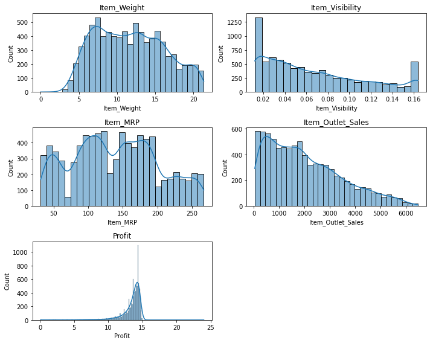

```python
# Plotting to check normality of data

plt.figure(figsize=(10,8))

c = 1
for i in num_cols:
    plt.subplot(3,2,c)
    sns.histplot(x = sales[i], data=sales, kde= True)
    c += 1
    plt.title(i)
plt.tight_layout()
plt.show()
```

```python
cat_cols = ['Item_Fat_Content', 'Item_Type', 'Outlet_Identifier', 'Outlet_Size',
 'Outlet_Location_Type', 'Outlet_Type', 'Outlet_Establishment_Year']
```

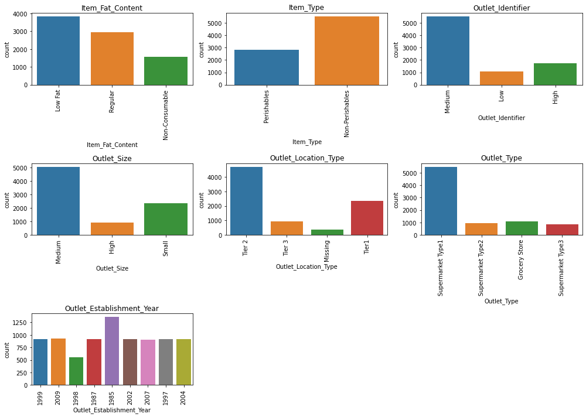

```python
# Plotting Categorical Columns

plt.figure(figsize=(14,10))

c = 1
for i in cat_cols:
    plt.subplot(3,3,c)
    sns.countplot(x = sales[i], data = sales)
    c += 1
    plt.title(i)
    plt.xticks(rotation=90)
plt.tight_layout()
plt.show()
```

##### Findings

# Extra Experimental Part

### Scaling

```python
from scipy.stats import stats
```

```python
zscore = pd.DataFrame(stats.zscore(sales[num_cols]))
zscore
```

|  | Item_Weight | Item_Visibility | Item_MRP | Item_Outlet_Sales | Profit |
| --- | --- | --- | --- | --- | --- |
| 0 | -0.547885 | -1.080580 | 1.797829 | 1.181757 | -1.122709 |
| 1 | -1.306322 | -1.009848 | -1.476810 | -1.078707 | 0.519348 |
| 2 | 0.636892 | -1.064976 | 0.039437 | 0.057012 | 0.636637 |
| 3 | 1.673571 | -1.168330 | 0.697615 | -0.880277 | 0.108834 |
| 4 | -0.630909 | -1.168330 | -1.385803 | -0.700134 | 0.402058 |
| ... | ... | ... | ... | ... | ... |
| 8518 | -1.095396 | -0.188769 | 1.224158 | 0.524741 | 0.402058 |
| 8519 | -0.754323 | -0.403335 | -0.503356 | -1.006010 | 0.460703 |
| 8520 | -0.256179 | -0.661582 | -0.878762 | -0.563885 | -2.295606 |
| 8521 | -1.016859 | 1.747337 | -0.586238 | -0.115815 | 0.460703 |
| 8522 | -0.143984 | -0.449400 | -1.034774 | -0.857416 | 0.695282 |

8336 rows × 5 columns

```python
from sklearn.preprocessing import StandardScaler, MinMaxScaler, RobustScaler
```

```python
sc = StandardScaler()
mm = MinMaxScaler()
rs = RobustScaler()
```

```python
scaled_sc = pd.DataFrame(sc.fit_transform(sales[num_cols]), columns=num_cols)
scaled_sc
```

|  | Item_Weight | Item_Visibility | Item_MRP | Item_Outlet_Sales | Profit |
| --- | --- | --- | --- | --- | --- |
| 0 | -0.547885 | -1.080580 | 1.797829 | 1.181757 | -1.122709 |
| 1 | -1.306322 | -1.009848 | -1.476810 | -1.078707 | 0.519348 |
| 2 | 0.636892 | -1.064976 | 0.039437 | 0.057012 | 0.636637 |
| 3 | 1.673571 | -1.168330 | 0.697615 | -0.880277 | 0.108834 |
| 4 | -0.630909 | -1.168330 | -1.385803 | -0.700134 | 0.402058 |
| ... | ... | ... | ... | ... | ... |
| 8331 | -1.095396 | -0.188769 | 1.224158 | 0.524741 | 0.402058 |
| 8332 | -0.754323 | -0.403335 | -0.503356 | -1.006010 | 0.460703 |
| 8333 | -0.256179 | -0.661582 | -0.878762 | -0.563885 | -2.295606 |
| 8334 | -1.016859 | 1.747337 | -0.586238 | -0.115815 | 0.460703 |
| 8335 | -0.143984 | -0.449400 | -1.034774 | -0.857416 | 0.695282 |

8336 rows × 5 columns

```python
scaled_mm = pd.DataFrame(mm.fit_transform(sales[num_cols]), columns=num_cols)
scaled_mm
```

|  | Item_Weight | Item_Visibility | Item_MRP | Item_Outlet_Sales | Profit |
| --- | --- | --- | --- | --- | --- |
| 0 | 0.435597 | 0.026413 | 0.927419 | 0.574380 | 0.476987 |
| 1 | 0.277283 | 0.047703 | 0.072156 | 0.063636 | 0.594142 |
| 2 | 0.682904 | 0.031109 | 0.468166 | 0.320248 | 0.602510 |
| 3 | 0.899297 | 0.000000 | 0.640068 | 0.108471 | 0.564854 |
| 4 | 0.418267 | 0.000000 | 0.095925 | 0.149174 | 0.585774 |
| ... | ... | ... | ... | ... | ... |
| 8331 | 0.321311 | 0.294848 | 0.777589 | 0.425930 | 0.585774 |
| 8332 | 0.392506 | 0.230264 | 0.326401 | 0.080062 | 0.589958 |
| 8333 | 0.496487 | 0.152531 | 0.228353 | 0.179959 | 0.393305 |
| 8334 | 0.337705 | 0.877617 | 0.304754 | 0.281198 | 0.589958 |
| 8335 | 0.519906 | 0.216398 | 0.187606 | 0.113636 | 0.606695 |

8336 rows × 5 columns

```python
scaled_rs = pd.DataFrame(rs.fit_transform(sales[num_cols]), columns=num_cols)
scaled_rs
```

|  | Item_Weight | Item_Visibility | Item_MRP | Item_Outlet_Sales | Profit |
| --- | --- | --- | --- | --- | --- |
| 0 | -0.300958 | -0.555033 | 1.201103 | 0.927419 | -2.000000 |
| 1 | -0.763338 | -0.507715 | -1.022345 | -0.606079 | 0.333333 |
| 2 | 0.421341 | -0.544594 | 0.007172 | 0.164392 | 0.500000 |
| 3 | 1.053352 | -0.613736 | 0.454069 | -0.471464 | -0.250000 |
| 4 | -0.351573 | -0.613736 | -0.960552 | -0.349256 | 0.166667 |
| ... | ... | ... | ... | ... | ... |
| 8331 | -0.634747 | 0.041570 | 0.811586 | 0.481700 | 0.166667 |
| 8332 | -0.426813 | -0.101971 | -0.361379 | -0.556762 | 0.250000 |
| 8333 | -0.123119 | -0.274732 | -0.616276 | -0.256824 | -3.666667 |
| 8334 | -0.586867 | 1.336784 | -0.417655 | 0.047146 | 0.250000 |
| 8335 | -0.054720 | -0.132787 | -0.722207 | -0.455955 | 0.583333 |

8336 rows × 5 columns

### Encoding

```python
# dummy
pd.get_dummies(sales[cat_cols])
```

|  | Item_Fat_Content_Low Fat | Item_Fat_Content_Non-Consumable | Item_Fat_Content_Regular | Item_Type_Non-Perishables | Item_Type_Perishables | Outlet_Identifier_High | Outlet_Identifier_Low | Outlet_Identifier_Medium | Outlet_Size_High | Outlet_Size_Medium | ... | Outlet_Type_Supermarket Type3 | Outlet_Establishment_Year_1985 | Outlet_Establishment_Year_1987 | Outlet_Establishment_Year_1997 | Outlet_Establishment_Year_1998 | Outlet_Establishment_Year_1999 | Outlet_Establishment_Year_2002 | Outlet_Establishment_Year_2004 | Outlet_Establishment_Year_2007 | Outlet_Establishment_Year_2009 |
| --- | --- | --- | --- | --- | --- | --- | --- | --- | --- | --- | --- | --- | --- | --- | --- | --- | --- | --- | --- | --- | --- |
| 0 | 1 | 0 | 0 | 0 | 1 | 0 | 0 | 1 | 0 | 1 | ... | 0 | 0 | 0 | 0 | 0 | 1 | 0 | 0 | 0 | 0 |
| 1 | 0 | 0 | 1 | 1 | 0 | 0 | 0 | 1 | 0 | 1 | ... | 0 | 0 | 0 | 0 | 0 | 0 | 0 | 0 | 0 | 1 |
| 2 | 1 | 0 | 0 | 0 | 1 | 0 | 0 | 1 | 0 | 1 | ... | 0 | 0 | 0 | 0 | 0 | 1 | 0 | 0 | 0 | 0 |
| 3 | 0 | 0 | 1 | 0 | 1 | 0 | 1 | 0 | 0 | 1 | ... | 0 | 0 | 0 | 0 | 1 | 0 | 0 | 0 | 0 | 0 |
| 4 | 0 | 1 | 0 | 1 | 0 | 0 | 0 | 1 | 1 | 0 | ... | 0 | 0 | 1 | 0 | 0 | 0 | 0 | 0 | 0 | 0 |
| ... | ... | ... | ... | ... | ... | ... | ... | ... | ... | ... | ... | ... | ... | ... | ... | ... | ... | ... | ... | ... | ... |
| 8518 | 1 | 0 | 0 | 1 | 0 | 0 | 0 | 1 | 1 | 0 | ... | 0 | 0 | 1 | 0 | 0 | 0 | 0 | 0 | 0 | 0 |
| 8519 | 0 | 0 | 1 | 1 | 0 | 0 | 0 | 1 | 0 | 1 | ... | 0 | 0 | 0 | 0 | 0 | 0 | 1 | 0 | 0 | 0 |
| 8520 | 0 | 1 | 0 | 1 | 0 | 1 | 0 | 0 | 0 | 0 | ... | 0 | 0 | 0 | 0 | 0 | 0 | 0 | 1 | 0 | 0 |
| 8521 | 0 | 0 | 1 | 1 | 0 | 0 | 0 | 1 | 0 | 1 | ... | 0 | 0 | 0 | 0 | 0 | 0 | 0 | 0 | 0 | 1 |
| 8522 | 1 | 0 | 0 | 1 | 0 | 0 | 0 | 1 | 0 | 0 | ... | 0 | 0 | 0 | 1 | 0 | 0 | 0 | 0 | 0 | 0 |

8336 rows × 28 columns

```python
# One Hot (n-1)
pd.get_dummies(sales[cat_cols], drop_first = True)
```

|  | Item_Fat_Content_Non-Consumable | Item_Fat_Content_Regular | Item_Type_Perishables | Outlet_Identifier_Low | Outlet_Identifier_Medium | Outlet_Size_Medium | Outlet_Size_Small | Outlet_Location_Type_Tier 2 | Outlet_Location_Type_Tier 3 | Outlet_Location_Type_Tier1 | ... | Outlet_Type_Supermarket Type2 | Outlet_Type_Supermarket Type3 | Outlet_Establishment_Year_1987 | Outlet_Establishment_Year_1997 | Outlet_Establishment_Year_1998 | Outlet_Establishment_Year_1999 | Outlet_Establishment_Year_2002 | Outlet_Establishment_Year_2004 | Outlet_Establishment_Year_2007 | Outlet_Establishment_Year_2009 |
| --- | --- | --- | --- | --- | --- | --- | --- | --- | --- | --- | --- | --- | --- | --- | --- | --- | --- | --- | --- | --- | --- |
| 0 | 0 | 0 | 1 | 0 | 1 | 1 | 0 | 1 | 0 | 0 | ... | 0 | 0 | 0 | 0 | 0 | 1 | 0 | 0 | 0 | 0 |
| 1 | 0 | 1 | 0 | 0 | 1 | 1 | 0 | 1 | 0 | 0 | ... | 1 | 0 | 0 | 0 | 0 | 0 | 0 | 0 | 0 | 1 |
| 2 | 0 | 0 | 1 | 0 | 1 | 1 | 0 | 1 | 0 | 0 | ... | 0 | 0 | 0 | 0 | 0 | 1 | 0 | 0 | 0 | 0 |
| 3 | 0 | 1 | 1 | 1 | 0 | 1 | 0 | 1 | 0 | 0 | ... | 0 | 0 | 0 | 0 | 1 | 0 | 0 | 0 | 0 | 0 |
| 4 | 1 | 0 | 0 | 0 | 1 | 0 | 0 | 0 | 1 | 0 | ... | 0 | 0 | 1 | 0 | 0 | 0 | 0 | 0 | 0 | 0 |
| ... | ... | ... | ... | ... | ... | ... | ... | ... | ... | ... | ... | ... | ... | ... | ... | ... | ... | ... | ... | ... | ... |
| 8518 | 0 | 0 | 0 | 0 | 1 | 0 | 0 | 0 | 1 | 0 | ... | 0 | 0 | 1 | 0 | 0 | 0 | 0 | 0 | 0 | 0 |
| 8519 | 0 | 1 | 0 | 0 | 1 | 1 | 0 | 1 | 0 | 0 | ... | 0 | 0 | 0 | 0 | 0 | 0 | 1 | 0 | 0 | 0 |
| 8520 | 1 | 0 | 0 | 0 | 0 | 0 | 1 | 0 | 0 | 1 | ... | 0 | 0 | 0 | 0 | 0 | 0 | 0 | 1 | 0 | 0 |
| 8521 | 0 | 1 | 0 | 0 | 1 | 1 | 0 | 1 | 0 | 0 | ... | 1 | 0 | 0 | 0 | 0 | 0 | 0 | 0 | 0 | 1 |
| 8522 | 0 | 0 | 0 | 0 | 1 | 0 | 1 | 0 | 0 | 1 | ... | 0 | 0 | 0 | 1 | 0 | 0 | 0 | 0 | 0 | 0 |

8336 rows × 21 columns

### Splitting the data

```python
from sklearn.model_selection import train_test_split
# from sklearn.linear_model import LinearRegression   can also be used
```

```python
x = sales.drop("Item_Outlet_Sales", axis=1)
y = sales["Item_Outlet_Sales"]
```

```python
x_train, x_test, y_train, y_test = train_test_split(x,y, test_size=.20, random_state=0)
```

```python
x_train.shape, x_test.shape, y_train.shape, y_test.shape
```

```
((6668, 12), (1668, 12), (6668,), (1668,))
```

### Findings

- Performed the ML methods like :
  - Scaling using methods like *Zscore*, *Standard Scalar*, *MinMax Scaler* and *Robust Scalar*.
  - Encoded the data using methods like *Dummy Encoding*, *One - Hot Encoding*.
  - Splitting the data into *Train* and *Test* parts.